# My Simple Logistic Regression

## Background

Driving on a highway or freeway with an insane amount of vehicles has always fascinated me. I have lived in Idaho Falls my whole life, and we don’t have too many vehicles on the road. But every time I visit Vegas or Washington D.C., I am amazed at how many people drive to and from wherever. What also intrigues me in areas like this are accidents. I would have to assume that the more people driving, the larger the chance of getting into an accident. There just so happens to be a dataset called Highway that measured the amount of accidents in large highways in Minnesota in 1973. Clearly the data is old, but it will work, and I would guess it may still be applicable today. I want to use the average amount of accidents each day to find a probability of having more than 20,000 drivers (I think this is a lot, but it may not be) on the highway. I can use a logistic regression model to do this.

## Hypothesis

Similar to linear regression, we will have $\beta_1$ as our hypothesis variable. If $\beta_1 = 0$, then we don’t have any relation between the rate of accidents and the amount of drivers and we can’t create a probability of the number of drivers. but if $\beta_1 \neq 0$, then we have some sort of relation and we can indeed find the probability of the number of users. I will explain what this $\beta_1$ actually means later.

$$H_0: \beta_1 = 0$$
$$H_a: \beta_1 \neq 0$$

## Probability Graph

```r
highway.glm <- glm(adt>20 ~ rate, data=Highway, family=binomial)
b<-coef(highway.glm)
```

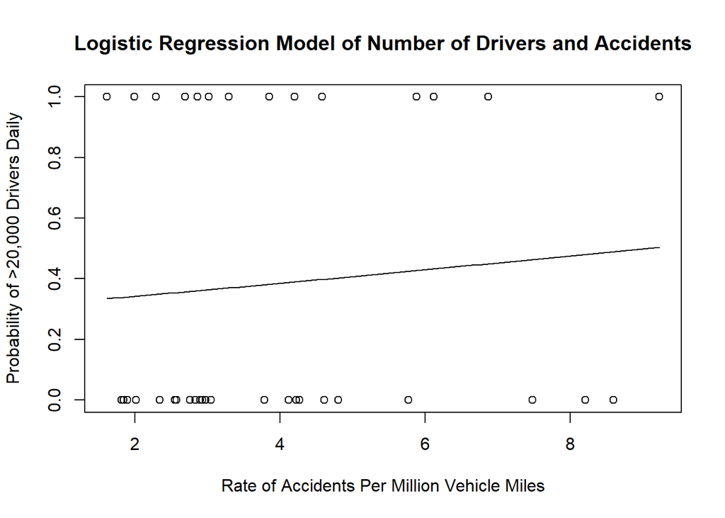

```r
plot(adt>20 ~ rate, data=Highway, xlab="Rate of Accidents Per Million Vehicle Miles", ylab= "Probability of >20,000 Drivers Daily", main="Logistic Regression Model of Number of Drivers and Accidents")
curve(exp(b[1]+b[2]*x)/(1+exp(b[1]+b[2]*x)), add=TRUE)
```

The above graph depicts the probability (the line) of having more than 20,000 people use the road daily based on the average amount of accidents (each point). A 1 on the y axis symbolizes more than 20,000 drivers and a 0 symbolizes anything under that amount. From the graph, the line increases the more accidents that happen, indicating the probability of having a ton of drivers increases the more accidents that happen. This is what I thought, and the graph seems to agree. However, how good of a fit is this probability line?

## Logistic Regression Model

##### Requirements

In order to test the accuracy/fit of the above probability line, we can use a Hosmer-Lemeshow Goodness of Fit Test. Basically this gives its own p-value for the fit of our probability line. If the value is less than .05, we can reject the null hypothesis that the probability line is a good fit for the data and say that our probability line isn’t a good fit, and a different/new approach needs to be taken. This will also double as a check to see if a logistic regression model is appropriate for this data.

```r
pander(hoslem.test(highway.glm$y, highway.glm$fitted, g=10))
```

Hosmer and Lemeshow goodness of fit (GOF) test: `highway.glm$y, highway.glm$fitted`

| Test statistic | df | P value |
| --- | --- | --- |
| 6.586 | 8 | 0.5819 |

From that test we get a p-value of .5819. So we don’t have sufficient evidence to reject the null and our probability line is a good fit! So we can continue with the test.

##### The Model

```r
pander(summary(highway.glm))
```

|  | Estimate | Std. Error | z value | Pr(>\|z\|) |
| --- | --- | --- | --- | --- |
| **(Intercept)** | -0.837 | 0.7421 | -1.128 | 0.2594 |
| **rate** | 0.09247 | 0.1662 | 0.5564 | 0.5779 |

(Dispersion parameter for binomial family taken to be 1 )

| Null deviance: | 51.97 on 38 degrees of freedom |
| --- | --- |
| Residual deviance: | 51.66 on 37 degrees of freedom |

The rate row underneath the Estimate column is the estimated value of $\beta_1$. That number is .09247. This number in and of itself doesn’t mean much. However, when we apply it to the exponential function $e^{\beta_1}$, we do get a meaningful number. This calculation of $e^{\beta_1} = 1.096881$, which means that per one unit increase of the rate of accidents, the probability of having more than 20,000 drivers increases by 9.6881%. We can use this number and model to predict the number of drivers given a number of accidents. For example, let’s say you know the number of accidents on a Minnesota highway is 5 on average. This model can tell us the probability that this highway has more than 20,000 users:

```r
pander(predict(highway.glm, newdata=data.frame(rate=5), type="response"))
```

| 1 |
| --- |
| 0.4074 |

So we have a 41% chance that this highway has more than 20,000 drivers knowing that the average number of accidents is 5. Pretty cool, right? However, look at the p-value for $\beta_1$. All of this fancy talk has gone under the assumption that we have a relation between the data. But the p-value is 0.5779. That means we fail to reject the null hypothesis. That means that $\beta_1 = 0$ and we can’t even make a probability line because their is no interaction. But if the p-value were to be less than .05, everything said above would be true.

## Conclusion

Again, this test gave an insignificant p-value. So we technically can’t make any sort of conjecture on the probability of having more than 20,000 drivers on a highway based on accidents alone. But their may be a column in the data set that could give a probability and I just didn’t choose it. Maybe the number of access points or number of lanes would be a better predictor.

##### Further Studies

Well, for starters it would be good to get up to date data. But it would be good to perform the model using the different columns of the dataset that may be a better choice. Someone could even dig into the archives of other states back in 1973 and compare how their highways differed form Minnesota. That would be an interesting comparison to see if the highways of each state accross the US behave the same. And then if they did that exact same comparison today, we could see how things have changed over the last 50 years. That would be pretty cool to see.